# EDA: Oxidative Stress, Inflammation, and Glucocorticoid Stress

#### Box Plots of biomarkers by full age sex classes

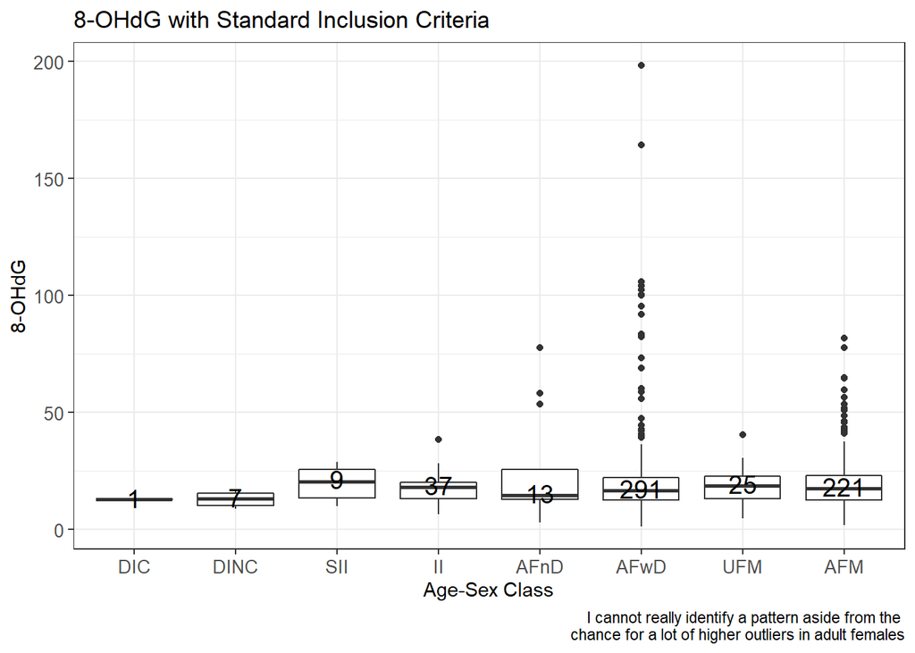

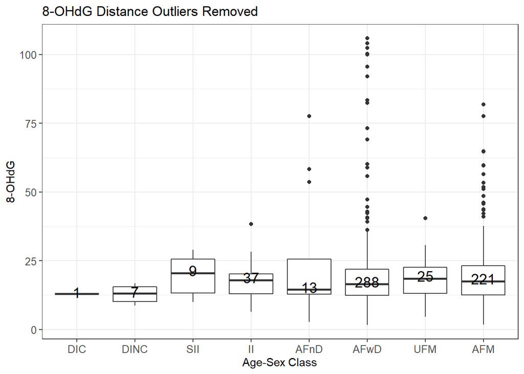

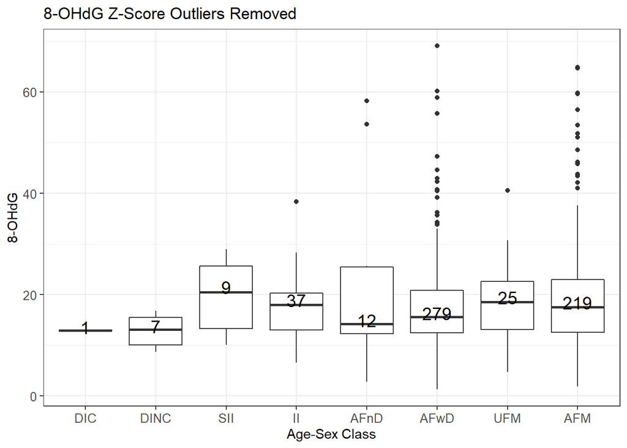

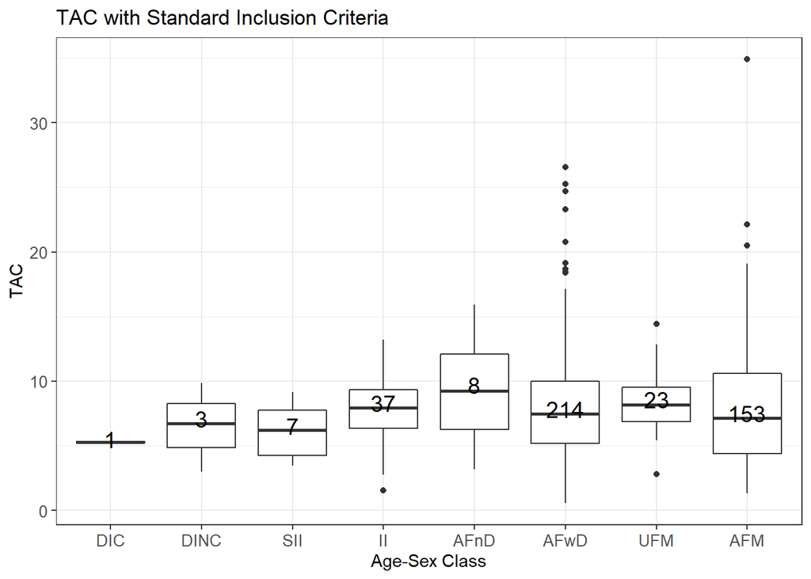

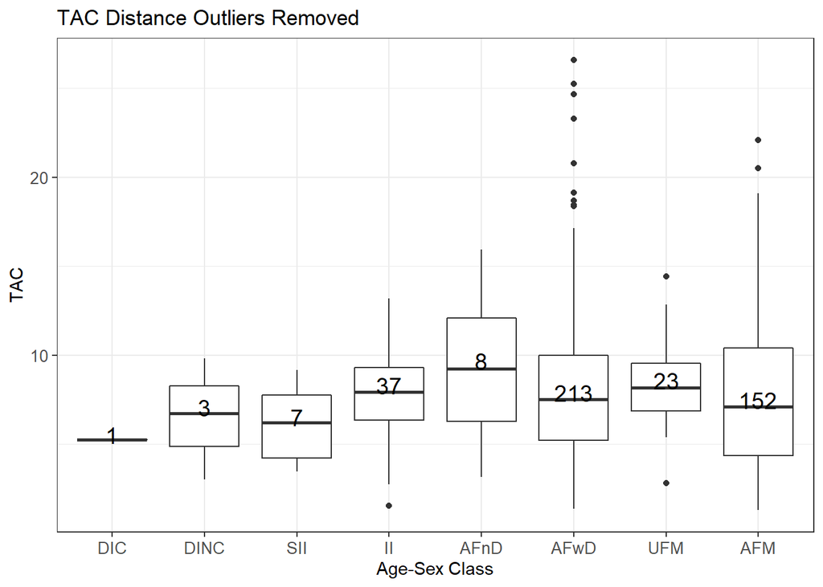

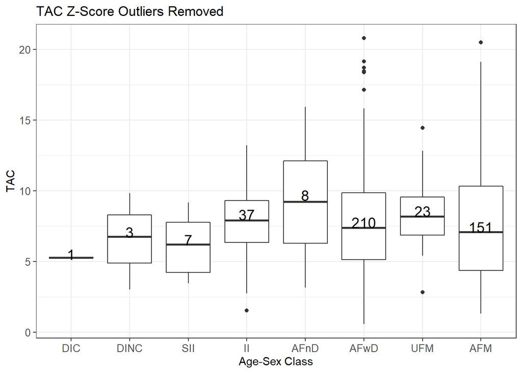

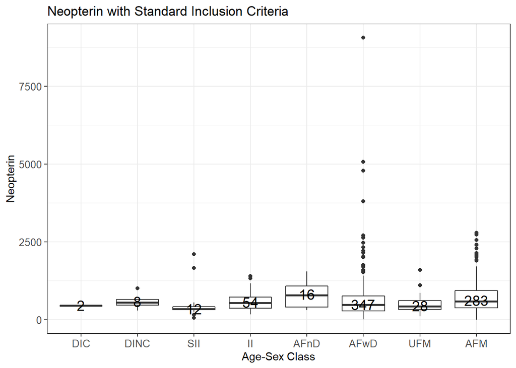

[figure not shown]

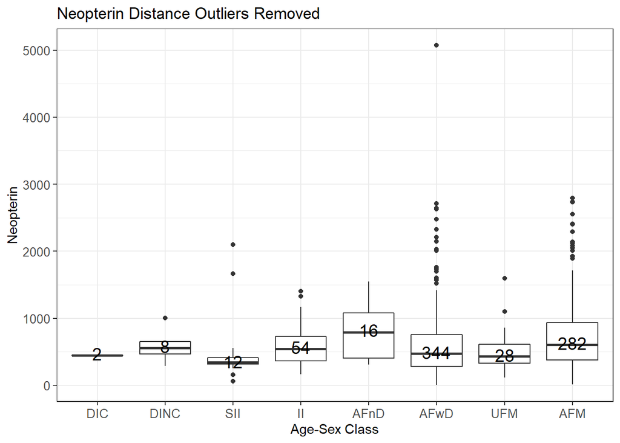

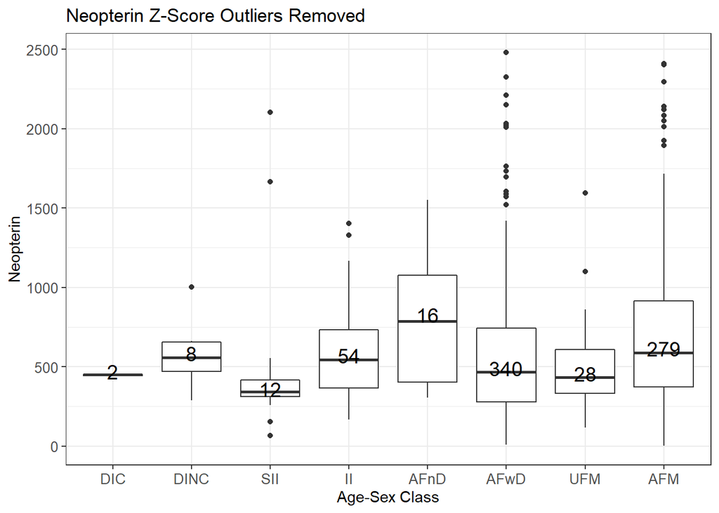

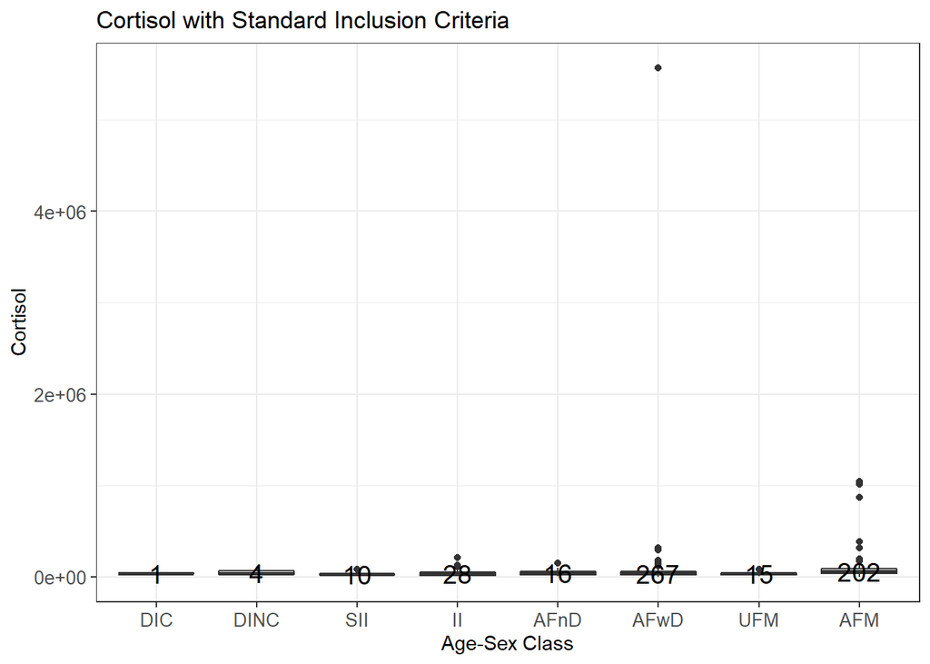

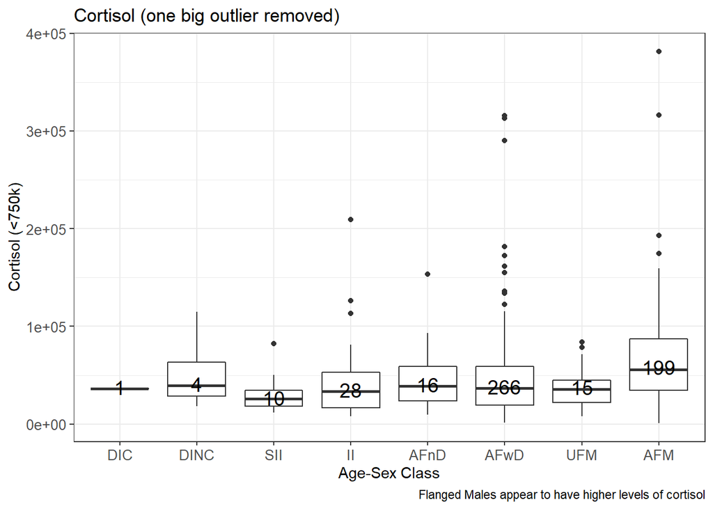

[4 more figures not shown]

#### Work on Distance Outlier Detection

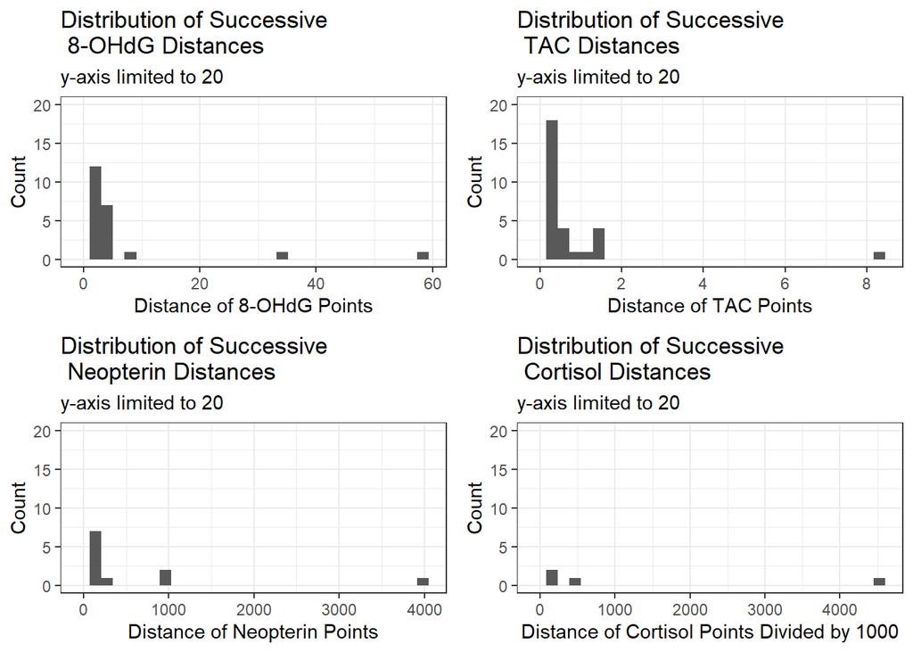

*Note: I went with the distance metric and that resulted in some of the distributions in the supplement of this document where I tried to determine the best link function for later GAMM fittings. There still appears to be some outliers, so perhaps I need to use the Z-score or 1.5 x IQR approach*

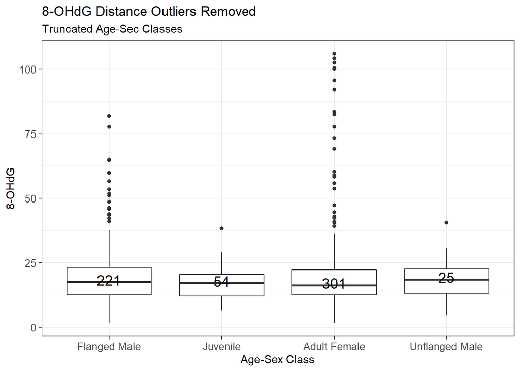

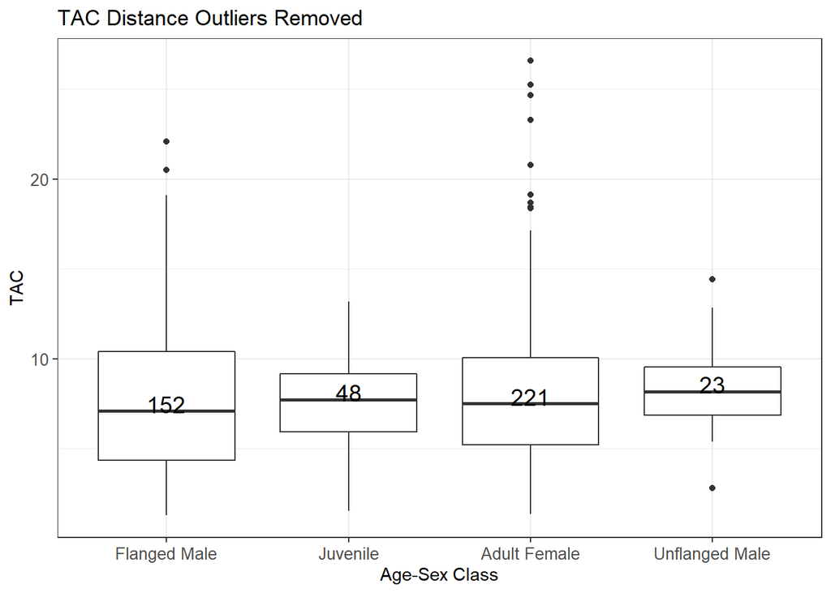

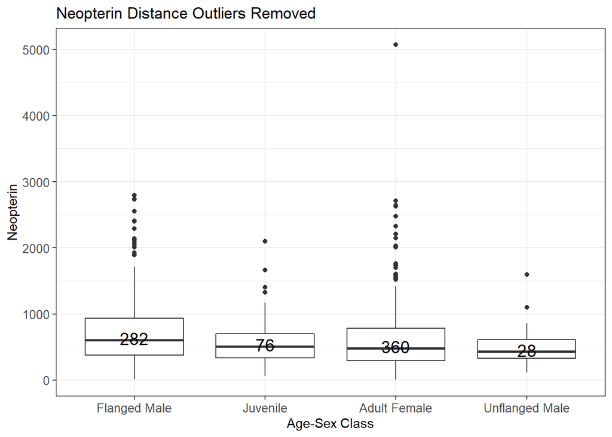

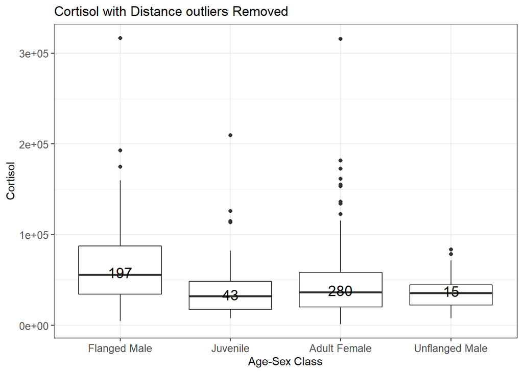

#### Biomarkers by FAI

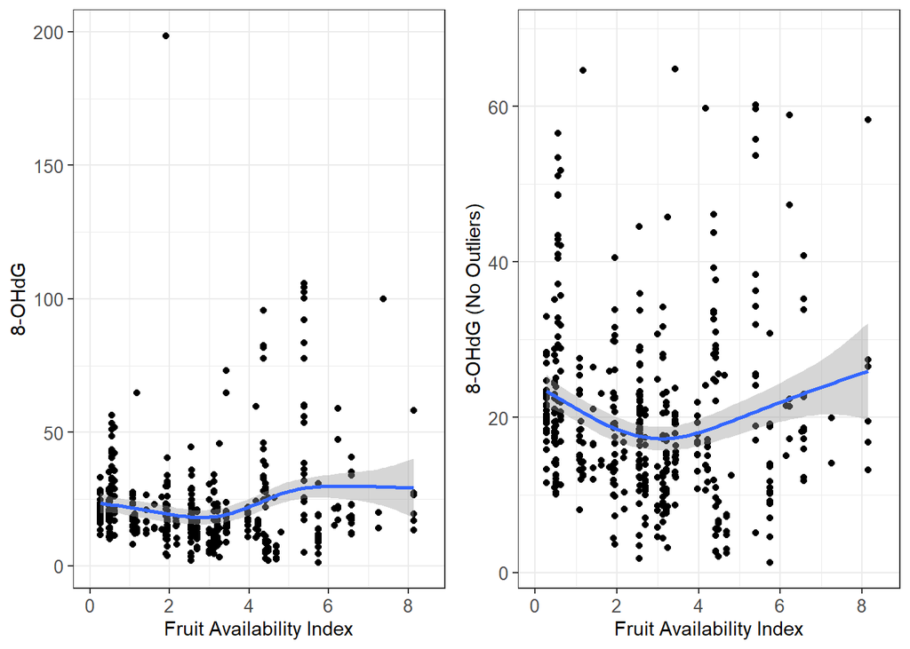

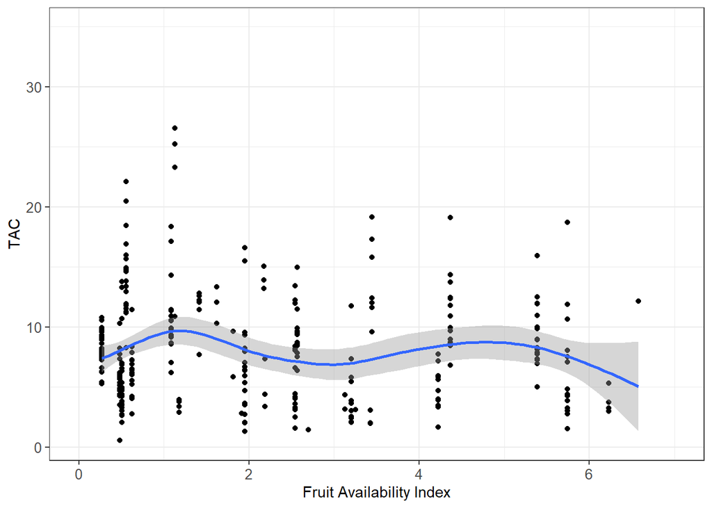

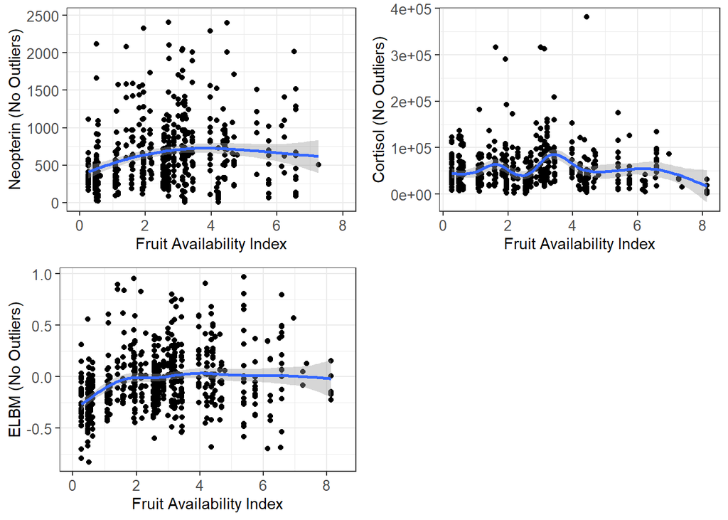

Both neopterin and ELBM seem to increase with FAI up to a point and then become stable; there is a rather wide spread to the data. This increase runs from 0 to 2% FAI, where caloric intake is most likely at it’s lowest and when orangutans might be undernourished. While an unsubstantiated statement, it makes sense that these relationships would be stable except in the extreme. The relationship between cortisol and FAI is almost nonsensical; further analysis has been disregarded. Conclusive statements will require modelling that accounts for individual variation.

#### Biomarkers by Select Forest Chemstrip Data

This part of the report was inspired by a paper talking about the effects of high glucose induced increases in oxidative stress episodes on myogenesis, particularly acceleration (Liu et al. 2020).

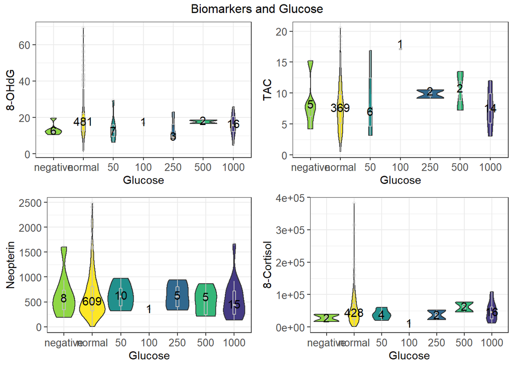

Given the tiny sample sizes with a glucose reading above normal, I doubt these distributions have any true relevance.

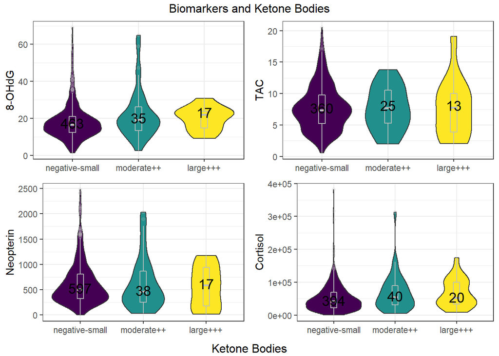

Based solely on violin plots, it looks like high levels of ketones *might* increase oxidative stress.

```
##
##  Maximum number of PQL iterations:  20
```

```
##
##  Maximum number of PQL iterations:  20
```

```
##
##  Maximum number of PQL iterations:  20
```

```
##
##  Maximum number of PQL iterations:  20
```

```
##
## Family: gaussian
## Link function: log
##
## Formula:
## ohdg_include ~ forest_ketones
##
## Parametric coefficients:
##                          Estimate Std. Error t value Pr(>|t|)
## (Intercept)               2.97642    0.04524  65.796  < 2e-16 ***
## forest_ketonesmoderate++  0.28884    0.10613   2.722  0.00672 **
## forest_ketoneslarge+++    0.05053    0.19226   0.263  0.79280
## ---
## Signif. codes:  0 '***' 0.001 '**' 0.01 '*' 0.05 '.' 0.1 ' ' 1
##
##
## R-sq.(adj) =  0.00519
##   Scale est. = 228.16    n = 525
```

```
##
## Family: Gamma
## Link function: inverse
##
## Formula:
## tac_include ~ forest_ketones
##
## Parametric coefficients:
##                          Estimate Std. Error t value Pr(>|t|)
## (Intercept)              0.125656   0.004623  27.181   <2e-16 ***
## forest_ketonesmoderate++ 0.006373   0.013727   0.464    0.643
## forest_ketoneslarge+++   0.003278   0.018773   0.175    0.861
## ---
## Signif. codes:  0 '***' 0.001 '**' 0.01 '*' 0.05 '.' 0.1 ' ' 1
##
##
## R-sq.(adj) =  -0.00439
##   Scale est. = 0.24007   n = 403
```

```
##
## Family: gaussian
## Link function: log
##
## Formula:
## tac_include ~ forest_ketones
##
## Parametric coefficients:
##                          Estimate Std. Error t value Pr(>|t|)
## (Intercept)               2.08882    0.03796  55.028   <2e-16 ***
## forest_ketonesmoderate++ -0.05012    0.11131  -0.450    0.653
## forest_ketoneslarge+++   -0.01018    0.15004  -0.068    0.946
## ---
## Signif. codes:  0 '***' 0.001 '**' 0.01 '*' 0.05 '.' 0.1 ' ' 1
##
##
## R-sq.(adj) =  -0.00448
##   Scale est. = 16.151    n = 403
```

```
##
## Family: Gamma
## Link function: inverse
##
## Formula:
## cort_include ~ forest_ketones
##
## Parametric coefficients:
##                            Estimate Std. Error t value Pr(>|t|)
## (Intercept)               2.012e-05  1.090e-06  18.465   <2e-16 ***
## forest_ketonesmoderate++ -3.767e-06  1.926e-06  -1.956   0.0511 .
## forest_ketoneslarge+++   -4.709e-06  2.529e-06  -1.862   0.0633 .
## ---
## Signif. codes:  0 '***' 0.001 '**' 0.01 '*' 0.05 '.' 0.1 ' ' 1
##
##
## R-sq.(adj) =  0.0132
##   Scale est. = 0.40256   n = 450
```

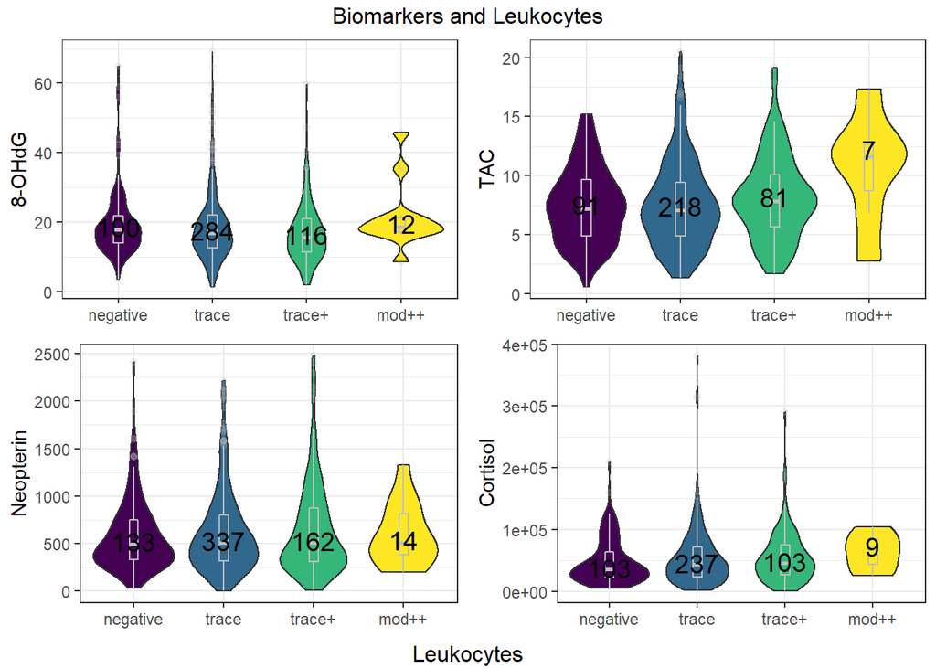

I’m not particularly seeing a relationship here. There looks like a steady positive increase in TAC might occur due to circulating leukocytes. The highest category always seems to be higher, but it has a full order of magnitude smaller a sample size so extreme caution should be taken in drawing any conclusions. The GAMM suggests thi strend is indeed true. Extremely low R squared adjusted though, and estimates are quite small.

```
##
##  Maximum number of PQL iterations:  20
```

```
##
## Family: Gamma
## Link function: inverse
##
## Formula:
## tac_include ~ forest_leukocytes
##
## Parametric coefficients:
##                          Estimate Std. Error t value Pr(>|t|)
## (Intercept)              0.134896   0.007511  17.959   <2e-16 ***
## forest_leukocytestrace  -0.003832   0.007981  -0.480   0.6314
## forest_leukocytestrace+ -0.023029   0.008979  -2.565   0.0107 *
## forest_leukocytesmod++  -0.047198   0.019161  -2.463   0.0142 *
## ---
## Signif. codes:  0 '***' 0.001 '**' 0.01 '*' 0.05 '.' 0.1 ' ' 1
##
##
## R-sq.(adj) =  0.0194
##   Scale est. = 0.2251    n = 402
```

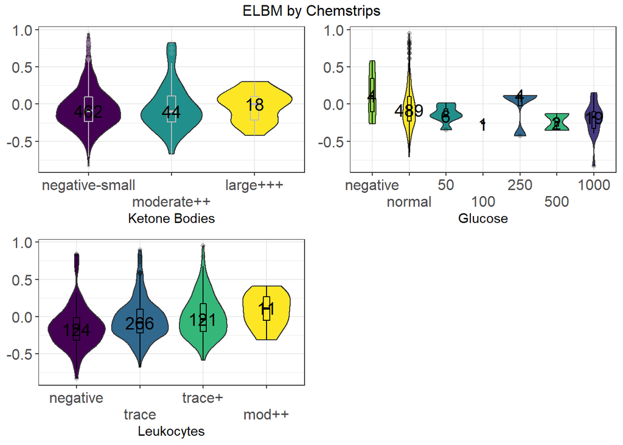

Very few samples are under the moderate and large categories of ketone bodies. It would appear that some degree of increase is found in the large category. I can’t really say anything about glucose. Seeing as all categories fall within the same rough range, particularly of the negative category. If these data are accurate, I’d say there really isn’t an effect. Likely the strips are simply not effective at measuring glucose. When it comes to white blood cells, there is some evidence of an increase in lean body mass. This begs the question of what the relationship between neopterin will be.

#### How many samples were collected by each field worker?

This first table will include all assayed samples, broken down by type of assay. All samples are included regardless of CV, whether it was a first morning void, whether it is too dilute, or taking any other considerations.

Table 1b: All assayed samples by which field worker collected them

| biomarker | Who_collected_clean | num_collected | prop_collected |
| --- | --- | --- | --- |
| 8-OHdG | Abuk | 182 | 24.53 |
| 8-OHdG | Abuk, Alysse | 1 | 0.13 |
| 8-OHdG | Allie | 7 | 0.94 |
| 8-OHdG | Alysse | 11 | 1.48 |
| 8-OHdG | Anna | 2 | 0.27 |
| 8-OHdG | Beth | 1 | 0.13 |
| 8-OHdG | Caco | 2 | 0.27 |
| 8-OHdG | Cecilia | 2 | 0.27 |
| 8-OHdG | Conor | 3 | 0.40 |
| 8-OHdG | Conor, Ellie | 1 | 0.13 |
| 8-OHdG | Daniel | 4 | 0.54 |
| 8-OHdG | Ellie | 6 | 0.81 |
| 8-OHdG | Erin | 1 | 0.13 |
| 8-OHdG | Idun | 135 | 18.19 |
| 8-OHdG | Idun and Tim | 1 | 0.13 |
| 8-OHdG | Idun/Alysse | 1 | 0.13 |
| 8-OHdG | Isman | 82 | 11.05 |
| 8-OHdG | Jade | 2 | 0.27 |
| 8-OHdG | Jade, Hanon? | 1 | 0.13 |
| 8-OHdG | Julia | 13 | 1.75 |
| 8-OHdG | Kumpo | 1 | 0.13 |
| 8-OHdG | Lady | 1 | 0.13 |
| 8-OHdG | Manon | 2 | 0.27 |
| 8-OHdG | Misdi | 1 | 0.13 |
| 8-OHdG | Paige | 7 | 0.94 |
| 8-OHdG | Pawel, Kumpo | 1 | 0.13 |
| 8-OHdG | Rahmadt | 32 | 4.31 |
| 8-OHdG | Rahmatol | 1 | 0.13 |
| 8-OHdG | Rebecca | 10 | 1.35 |
| 8-OHdG | Rumaan | 1 | 0.13 |

[output cut: 388 more lines]